# Database Course Homework 7: Trump's Tweets

In this homework, I will figure out the following 2 questions:

1. On what kind of device (iPhone or an Andriod phone, etc.) were these tweets sent?
2. On what time were these tweets sent?

## by Fenglei Gu fg1121

> Data Scource: Baumgartner, Jason, 2019, "realdonaldtrump.ndjson", *Twitter Tweets for Donald J. Trump (@realdonaldtrump)*, https://doi.org/10.7910/DVN/KJEBIL/ADNH3U, Harvard Dataverse, V1

## Preparation Works

1: Basic configurations

```python
import csv
import numpy as np
import pandas as pd
import matplotlib.pyplot as plt
%matplotlib inline
plt.style.use('fivethirtyeight')
import seaborn as sns
sns.set()
sns.set_context("talk")
import re
```

2: Load Data

The original dataset is about 110 MB, please be patient

```python
def load_tweets(path):
    with open(path,'r',encoding="utf-8") as f:
        import ndjson
        return ndjson.load(f)
```

```python
file_path='realdonaldtrump.ndjson'
trump_tweets_all = load_tweets(file_path)
```

```python
trump_tweets_all[0].keys()
```

[output not shown]

3: Transform data into Pandas Dataframe

Note that I am only interested Trump's tweets since 2016 (under universal time zone).

Still, the dataset is big, so it might take some time

```python
idx=[]
dt={'time':[],'source':[]}
for twt in trump_tweets_all:
    if eval(twt['created_at'][-4:]) < 2016:
        continue
    else:
        idx.append(twt['id'])
        dt['time'].append(pd.to_datetime(twt['created_at']))
        dt['source'].append(twt.get('source',''))
trump = pd.DataFrame(data=dt,index=idx)
trump.head()
```

|  | time | source |
| --- | --- | --- |
| 682723973449289728 | 2016-01-01 00:44:14+00:00 | <a href="http://twitter.com/download/android" ... |
| 682764544402440192 | 2016-01-01 03:25:27+00:00 | <a href="http://twitter.com/download/iphone" r... |
| 682792967736848385 | 2016-01-01 05:18:23+00:00 | <a href="http://twitter.com/download/iphone" r... |
| 682805320217980929 | 2016-01-01 06:07:28+00:00 | <a href="http://twitter.com/download/iphone" r... |
| 682805477168779264 | 2016-01-01 06:08:06+00:00 | <a href="http://twitter.com/download/android" ... |

4: Data Cleaning

1. Remove the HTML tags in `source`
2. Transform UTC to Eastern Standard Time. The two entries showing EST in 2015 are actually in 2016 under UTC.
3. Create continuous parameter `year`.

```python
r = lambda x : x.group(0).split("</")[-2].split('>')[-1]
trump['source'] = trump['source'].str.replace(r'<a.*</a>',repl=r)
```

```python
import datetime

def year_fraction(date):
    start = datetime.date(date.year, 1, 1).toordinal()
    year_length = datetime.date(date.year+1, 1, 1).toordinal() - start
    return date.year + float(date.toordinal() - start) / year_length

trump['est'] = (trump['time'].dt.tz_convert("EST"))
trump['hour'] = trump['est'].apply(lambda x : (x.hour + x.minute /60 + x.second /3600))
trump['year'] = trump['time'].apply(year_fraction)
trump.head()
```

|  | time | source | est | hour | year |
| --- | --- | --- | --- | --- | --- |
| 682723973449289728 | 2016-01-01 00:44:14+00:00 | Twitter for Android | 2015-12-31 19:44:14-05:00 | 19.737222 | 2016.0 |
| 682764544402440192 | 2016-01-01 03:25:27+00:00 | Twitter for iPhone | 2015-12-31 22:25:27-05:00 | 22.424167 | 2016.0 |
| 682792967736848385 | 2016-01-01 05:18:23+00:00 | Twitter for iPhone | 2016-01-01 00:18:23-05:00 | 0.306389 | 2016.0 |
| 682805320217980929 | 2016-01-01 06:07:28+00:00 | Twitter for iPhone | 2016-01-01 01:07:28-05:00 | 1.124444 | 2016.0 |
| 682805477168779264 | 2016-01-01 06:08:06+00:00 | Twitter for Android | 2016-01-01 01:08:06-05:00 | 1.135000 | 2016.0 |

## What kind of devices were used?

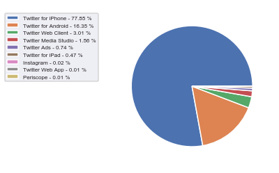

```python
# Source: https://doi.org/10.7910/DVN/KJEBIL/ADNH3U

source = trump['source'].value_counts()

x = source.index.tolist()
y = source.values
percent = 100.*y/y.sum()

patches, texts = plt.pie(y)
labels = ['{0} - {1:1.2f} %'.format(i,j) for i,j in zip(x, percent)]
patches, labels, dummy =  zip(*sorted(zip(patches, labels, y),key=lambda x: x[2],reverse=True))
plt.legend(patches, labels, bbox_to_anchor=(-0.1, 1.),fontsize=8)
plt.show()
```

**The pie chart above shows that most of Trumps' tweets were sent on iPhone, and a significant proportion were sent on an Android device, whereas there are also several other platforms. This pie chart might be useful for those intersted in Trump's behavior.**

Since just a few of his tweets were not sent through iPhone nor Android, we'll focuse on iOS and Android below.

## At what time of a day were Trump's tweets sent?

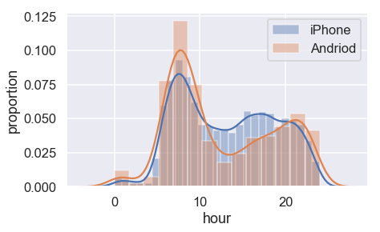

```python
# Source: https://doi.org/10.7910/DVN/KJEBIL/ADNH3U
sns.distplot(trump[trump['source']=='Twitter for iPhone']['hour'], label = 'iPhone')
sns.distplot(trump[trump['source']=='Twitter for Android']['hour'], label = 'Andriod')
plt.xlabel('hour')
plt.ylabel('proportion')
plt.legend()
plt.show()
```

### with interactive time

Above are the result of all data since 2016. Now, it's time for the user to input a year (2016,2017,2018,2019) to see the result within that year!

```python
while True:
    s=input('Enter the year you want:')
    try:
        yr=eval(s)
    except:
        print('Not a number!')
        continue
    else:
        if type(yr)==type(2016):
            if ( yr<2016 or yr>2020 ):
                print('Not in 2016~2019!')
            else:
                break
        else:
            print('Not a valid year number!')
print('You selected Year {}!'.format(yr))
```

```
Enter the year you want:2017.0
Not a valid year number!
Enter the year you want:'17
Not a number!
Enter the year you want:2021
Not in 2016~2019!
Enter the year you want:2017
You selected Year 2017!
```

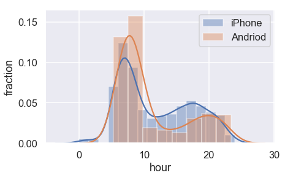

```python
# Source: https://doi.org/10.7910/DVN/KJEBIL/ADNH3U
trump2 = trump[(trump['year'] >= yr) & (trump['year'] < yr+1)]
sns.distplot(trump2[trump2['source']=='Twitter for iPhone']['hour'], label = 'iPhone')
sns.distplot(trump2[trump2['source']=='Twitter for Android']['hour'], label = 'Andriod')
plt.xlabel('hour')
plt.ylabel('fraction')
plt.legend()
plt.show()
```

## What about distribution on a long scale of time?

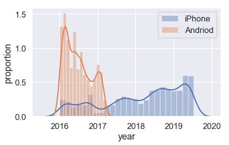

```python
# Source: https://doi.org/10.7910/DVN/KJEBIL/ADNH3U
sns.distplot(trump[trump['source']=='Twitter for iPhone']['year'], label = 'iPhone')
sns.distplot(trump[trump['source']=='Twitter for Android']['year'], label = 'Andriod')
plt.xlabel('year')
plt.ylabel('proportion')
plt.legend()
plt.show()
```

**The plot indicates that Trump used to be using an Android device, yet has switched to an iPhone.**